# Time to Positivity & Antibiotic Failure in Bacteremia: Bayesian Meta-Analysis

Author

Russell Lewis

Published

February 13, 2026

# 1 Introduction

## 1.1 Background

Blood culture time to positivity (TTP) — the interval between blood culture incubation and detection of microbial growth — has emerged as a potential prognostic marker in bacteremia. Shorter TTP is hypothesized to reflect higher bacterial inocula, which may signal more severe infection, greater risk of treatment failure, and higher mortality.

This meta-analysis systematically synthesizes the evidence on the association between short TTP and two primary clinical outcomes:

1. **Mortality** (all-cause, typically 30-day or in-hospital)
2. **Persistent bacteremia** (including microbiological clearance failure)

## 1.2 Analytical Approach

We employ a Bayesian random-effects framework using `brms` with weakly informative priors, complemented by frequentist models via `metafor` for validation. The analysis includes:

- Effect size computation from heterogeneous reporting formats (2×2 tables, adjusted/unadjusted OR/HR/RR, continuous TTP associations)
- Random-effects pooling with REML (frequentist) and Bayesian estimation
- Publication bias assessment (funnel plots, Egger’s test, trim-and-fill)
- Sensitivity analyses (outlier exclusion, prior specification)
- Meta-regression for moderator effects (pathogen class, organism, risk of bias, blood culture system)

# 2 Data Loading & Preparation

## 2.1 Load Packages

```r
library(tidyverse)
library(readxl)
library(janitor)
library(metafor)
library(brms)
library(posterior)
library(bayesplot)
library(ggdist)
library(patchwork)

color_scheme_set("viridis")
theme_set(theme_minimal(base_size = 12))

# Detect Stan backend
stan_backend <- if (requireNamespace("cmdstanr", quietly = TRUE)) "cmdstanr" else "rstan"
```

## 2.2 Load Database

The extraction database is stored as an Excel workbook with one sheet per table, following the relational structure outlined in the analysis protocol.

```r
path <- "/Users/russelllewis/Desktop/ttp_meta_final/TTP_MetaAnalysis_Extraction_Complete.xlsx"

tbl_study      <- read_excel(path, sheet = "tbl_study") |> clean_names()
tbl_population <- read_excel(path, sheet = "tbl_population") |> clean_names()
tbl_ttp        <- read_excel(path, sheet = "tbl_ttp") |> clean_names()
tbl_outcomes   <- read_excel(path, sheet = "tbl_outcomes") |> clean_names()
```

```r
tibble(
  Table = c("tbl_study", "tbl_population", "tbl_ttp", "tbl_outcomes"),
  Rows = c(nrow(tbl_study), nrow(tbl_population), nrow(tbl_ttp), nrow(tbl_outcomes)),
  Columns = c(ncol(tbl_study), ncol(tbl_population), ncol(tbl_ttp), ncol(tbl_outcomes))
)
```

```
# A tibble: 4 × 3
  Table           Rows Columns
  <chr>          <int>   <int>
1 tbl_study         57      19
2 tbl_population    57      23
3 tbl_ttp           57      21
4 tbl_outcomes      88      23
```

## 2.3 Data Cleaning

### 2.3.1 Remove Non-PICO Entries and Harmonize Outcome Types

Rows flagged as `[NON-PICO]` in the notes field represent outcomes outside the primary review question (e.g., septic shock, endocarditis as a diagnostic marker, catheter-related BSI). These are excluded before analysis.

```r
outcomes_clean <- tbl_outcomes |>
  # Remove NON-PICO

  filter(is.na(notes) | !str_detect(notes, "\\[NON-PICO\\]")) |>
  # Remove row with no outcome type
  filter(!is.na(outcome_type)) |>
  # Harmonize outcome types
  mutate(
    outcome_type_clean = case_when(
      outcome_type %in% c("mortality", "in_hospital_mortality") ~ "mortality",
      outcome_type %in% c("persistent_bacteremia", "bacteremia_clearance",
                          "microbiological_clearance", "bacteremia_classification") ~ "persistent_bacteremia",
      outcome_type %in% c("endocarditis", "infective_endocarditis",
                          "endovascular_infection") ~ "endocarditis_endovascular",
      outcome_type %in% c("sepsis_severity_mortality", "disease_severity",
                          "organ_dysfunction") ~ "severity",
      TRUE ~ outcome_type
    )
  ) |>
  # Classify effect size source
  mutate(
    has_2x2 = !is.na(events_short_ttp) & !is.na(events_long_ttp) &
              !is.na(n_short_ttp) & !is.na(n_long_ttp),
    has_effect_ci = !is.na(effect_estimate) & !is.na(ci_lower) & !is.na(ci_upper) &
                    effect_measure %in% c("OR", "HR", "RR"),
    has_or_per_hour = !is.na(or_per_hour) & !is.na(or_per_hour_ci_low) & !is.na(or_per_hour_ci_high),
    es_source = case_when(
      has_2x2 & has_effect_ci & adjusted ~ "reported_adjusted",
      has_2x2 & has_effect_ci & !adjusted ~ "reported_unadjusted",
      has_2x2 ~ "two_by_two",
      has_effect_ci & adjusted ~ "reported_adjusted",
      has_effect_ci ~ "reported_unadjusted",
      has_or_per_hour ~ "continuous_converted",
      TRUE ~ "insufficient_data"
    )
  )
```

```r
cat("Original outcome rows:", nrow(tbl_outcomes), "\n")
```

```
Original outcome rows: 88
```

```r
cat("After removing NON-PICO:", nrow(outcomes_clean), "\n\n")
```

```
After removing NON-PICO: 66
```

```r
outcomes_clean |> count(outcome_type_clean, sort = TRUE)
```

```
# A tibble: 5 × 2
  outcome_type_clean            n
  <chr>                     <int>
1 mortality                    49
2 persistent_bacteremia        12
3 severity                      3
4 endocarditis_endovascular     1
5 icu_length_of_stay            1
```

## 2.4 Effect Size Computation

Effect sizes are computed as log-odds ratios (log-OR) with associated sampling variances, following the hierarchy specified in the protocol:

1. **Reported adjusted estimates preferred** over unadjusted
2. **2×2 tables** used when no reported effect available
3. **Continuous TTP effects** (OR per hour) kept separate

### 2.4.1 From 2×2 Tables

```r
rows_2x2 <- outcomes_clean |> filter(es_source == "two_by_two")

es_2x2 <- escalc(
  measure = "OR",
  ai = rows_2x2$events_short_ttp,
  bi = rows_2x2$n_short_ttp - rows_2x2$events_short_ttp,
  ci = rows_2x2$events_long_ttp,
  di = rows_2x2$n_long_ttp - rows_2x2$events_long_ttp,
  data = rows_2x2
) |>
  as.data.frame() |>
  mutate(yi = as.numeric(yi), vi = as.numeric(vi), sei = sqrt(vi))
```

### 2.4.2 From Reported Effect Estimates (OR/HR/RR with CI)

```r
rows_reported <- outcomes_clean |>
  filter(es_source %in% c("reported_adjusted", "reported_unadjusted"))

es_reported <- rows_reported |>
  mutate(
    yi = log(effect_estimate),
    sei = (log(ci_upper) - log(ci_lower)) / (2 * 1.96),
    vi = sei^2
  )
```

### 2.4.3 From Continuous TTP (OR per Hour)

```r
es_continuous_1 <- outcomes_clean |>
  filter(es_source == "continuous_converted") |>
  mutate(
    yi = log(or_per_hour),
    sei = (log(or_per_hour_ci_high) - log(or_per_hour_ci_low)) / (2 * 1.96),
    vi = sei^2
  )

# SantosPatarroyo2025 has beta_per_hour (already log-OR scale)
es_continuous_2 <- outcomes_clean |>
  filter(study_id == "SantosPatarroyo2025") |>
  mutate(
    yi = beta_per_hour,
    sei = (ci_upper - ci_lower) / (2 * 1.96),
    vi = sei^2,
    es_source = "continuous_converted"
  )
```

### 2.4.4 Combine and Deduplicate

```r
common_cols <- c("study_id", "arm_id", "outcome_type_clean", "outcome_definition",
                 "outcome_timepoint_days", "effect_measure", "effect_estimate",
                 "adjusted", "adjustment_vars", "yi", "sei", "vi", "es_source")

tbl_es_combined <- bind_rows(
  es_2x2 |> select(any_of(common_cols)),
  es_reported |> select(any_of(common_cols)),
  bind_rows(es_continuous_1, es_continuous_2) |> select(any_of(common_cols))
)

# Deduplication rules:
# - Prefer adjusted over unadjusted (Cilloniz2017, Hou2023)
# - Remove extreme sparse-cell row (Melling2019 OR=1722)
tbl_es <- tbl_es_combined |>
  filter(!(study_id == "Cilloniz2017" & adjusted == FALSE)) |>
  filter(!(study_id == "Hou2023" & adjusted == FALSE)) |>
  filter(!(study_id == "Melling2019" & yi > 5))
```

### 2.4.5 Merge Moderator Variables

```r
tbl_es <- tbl_es |>
  left_join(
    tbl_population |>
      select(study_id, n_total, pathogen_class, pathogen_species,
             infection_source, source_control, pct_icu,
             severity_score_type, pct_appropriate_empiric, blood_culture_system),
    by = "study_id"
  ) |>
  left_join(
    tbl_ttp |> select(study_id, ttp_cutpoint_hours, ttp_cutpoint_basis),
    by = "study_id"
  ) |>
  left_join(
    tbl_study |> select(study_id, rob_overall, pub_year, country, study_design),
    by = "study_id"
  ) |>
  mutate(
    organism_saureus = str_detect(pathogen_species, regex("aureus", ignore_case = TRUE)),
    ni = n_total,
    es_id = row_number(),
    rob_binary = ifelse(rob_overall == "low", "low", "moderate_high"),
    blood_culture_system_clean = case_when(
      str_detect(blood_culture_system, regex("BacTALERT|BACT/ALERT|BacT/Alert", ignore_case = TRUE)) ~ "BacTALERT",
      str_detect(blood_culture_system, regex("BACTEC", ignore_case = TRUE)) ~ "BACTEC",
      str_detect(blood_culture_system, regex("VersaTREK", ignore_case = TRUE)) ~ "VersaTREK",
      str_detect(blood_culture_system, regex("automated|other", ignore_case = TRUE)) ~ "other",
      blood_culture_system == "NR" ~ "NR",
      TRUE ~ NA_character_
    ),
    bcs_binary = case_when(
      blood_culture_system_clean == "BACTEC" ~ "BACTEC",
      blood_culture_system_clean == "BacTALERT" ~ "BacTALERT",
      TRUE ~ "other"
    )
  )
```

```r
cat("Final tbl_es:", nrow(tbl_es), "effect sizes from", n_distinct(tbl_es$study_id), "studies\n\n")
```

```
Final tbl_es: 42 effect sizes from 38 studies
```

```r
tbl_es |> count(outcome_type_clean, es_source) |>
  pivot_wider(names_from = es_source, values_from = n, values_fill = 0)
```

```
# A tibble: 2 × 5
  outcome_type_clean    reported_adjusted reported_unadjusted two_by_two
  <chr>                             <int>               <int>      <int>
1 mortality                            25                   5          3
2 persistent_bacteremia                 4                   0          3
# ℹ 1 more variable: continuous_converted <int>
```

# 3 Descriptive Summary

## 3.1 Study Characteristics

```r
tbl_study |>
  summarise(
    `N studies` = as.character(n()),
    `Publication years` = paste0(min(pub_year), "–", max(pub_year)),
    `Prospective (%)` = as.character(round(100 * mean(study_design == "prospective_cohort"), 1)),
    `Single-center (%)` = as.character(round(100 * mean(single_center, na.rm = TRUE), 1)),
    `ROB low (%)` = as.character(round(100 * mean(rob_overall == "low"), 1)),
    `ROB moderate (%)` = as.character(round(100 * mean(rob_overall == "moderate"), 1))
  ) |>
  pivot_longer(everything(), names_to = "Characteristic", values_to = "Value")
```

Table 1: Study characteristics overview

```
# A tibble: 6 × 2
  Characteristic    Value
  <chr>             <chr>
1 N studies         57
2 Publication years 2005–2026
3 Prospective (%)   22.8
4 Single-center (%) 67.9
5 ROB low (%)       26.3
6 ROB moderate (%)  68.4
```

## 3.2 Effect Size Distributions

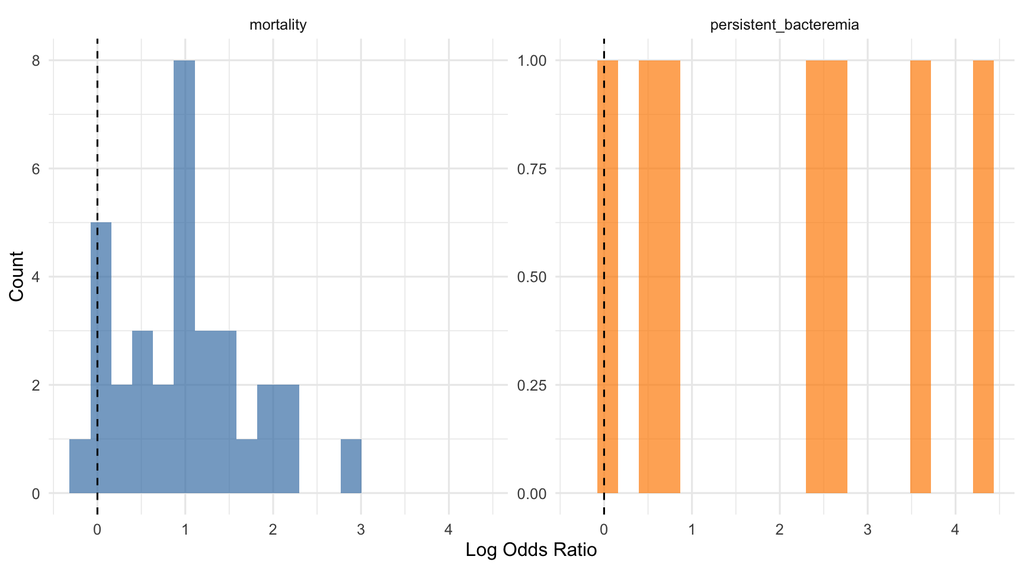

Figure 1: Distribution of log-OR effect sizes by outcome

```r
tbl_es |>
  filter(es_source != "continuous_converted") |>
  ggplot(aes(x = yi, fill = outcome_type_clean)) +
  geom_histogram(bins = 20, alpha = 0.7, position = "identity") +
  geom_vline(xintercept = 0, linetype = "dashed") +
  facet_wrap(~outcome_type_clean, scales = "free_y") +
  labs(x = "Log Odds Ratio", y = "Count", fill = "Outcome") +
  scale_fill_manual(values = c("mortality" = "steelblue", "persistent_bacteremia" = "darkorange")) +
  theme(legend.position = "none")
```

## 3.3 Moderator Completeness

```r
tbl_es |>
  summarise(
    across(c(pathogen_class, organism_saureus, infection_source,
             rob_overall, pub_year, blood_culture_system_clean, ttp_cutpoint_hours),
           ~sum(!is.na(.)))
  ) |>
  pivot_longer(everything(), names_to = "Moderator", values_to = "N_complete") |>
  mutate(
    N_total = nrow(tbl_es),
    Pct_complete = round(100 * N_complete / N_total, 1)
  )
```

Table 2: Moderator variable completeness in tbl_es

```
# A tibble: 7 × 4
  Moderator                  N_complete N_total Pct_complete
  <chr>                           <int>   <int>        <dbl>
1 pathogen_class                     42      42        100
2 organism_saureus                   42      42        100
3 infection_source                   42      42        100
4 rob_overall                        42      42        100
5 pub_year                           42      42        100
6 blood_culture_system_clean         41      42         97.6
7 ttp_cutpoint_hours                 32      42         76.2
```

# 4 Primary Meta-Analysis

We fit parallel frequentist (REML) and Bayesian random-effects models for each outcome. The Bayesian models serve as the primary analysis; frequentist results are reported for validation and comparison with prior literature.

## 4.1 Subset Preparation

```r
# Dichotomous effects only (exclude continuous OR-per-hour)
es_dichot <- tbl_es |> filter(es_source != "continuous_converted")

es_mort <- es_dichot |> filter(outcome_type_clean == "mortality")
es_pb   <- es_dichot |> filter(outcome_type_clean == "persistent_bacteremia")

cat("Mortality studies:", nrow(es_mort), "\n")
```

```
Mortality studies: 33
```

```r
cat("Persistent bacteremia studies:", nrow(es_pb), "\n")
```

```
Persistent bacteremia studies: 7
```

## 4.2 Frequentist Random-Effects (REML)

```r
rma_mort <- rma(yi = yi, vi = vi, data = es_mort, method = "REML")
rma_pb   <- rma(yi = yi, vi = vi, data = es_pb, method = "REML")
```

```r
tibble(
  Outcome = c("Mortality", "Persistent Bacteremia"),
  k = c(rma_mort$k, rma_pb$k),
  `Pooled OR` = round(c(exp(coef(rma_mort)), exp(coef(rma_pb))), 2),
  `95% CI` = c(
    paste0(round(exp(rma_mort$ci.lb), 2), "–", round(exp(rma_mort$ci.ub), 2)),
    paste0(round(exp(rma_pb$ci.lb), 2), "–", round(exp(rma_pb$ci.ub), 2))
  ),
  tau = round(c(sqrt(rma_mort$tau2), sqrt(rma_pb$tau2)), 2),
  `I²` = paste0(round(c(rma_mort$I2, rma_pb$I2), 1), "%"),
  p = formatC(c(rma_mort$pval, rma_pb$pval), format = "e", digits = 2)
)
```

```
# A tibble: 2 × 7
  Outcome                   k `Pooled OR` `95% CI`     tau `I²`  p
  <chr>                 <int>       <dbl> <chr>      <dbl> <chr> <chr>
1 Mortality                33        2.18 1.72–2.75   0.57 99.3% 6.71e-11
2 Persistent Bacteremia     7        7.24 2.07–25.38  1.61 98.4% 1.98e-03
```

## 4.3 Bayesian Random-Effects Models

### 4.3.1 Prior Specification

The Bayesian models use weakly informative priors:

```r
meta_priors <- c(
  prior(normal(0, 1), class = "Intercept"),
  prior(cauchy(0, 0.5), class = "sd")
)
```

### 4.3.2 Mortality Model (k=33)

```r
fit_mort <- brm(
  yi | se(sei) ~ 1 + (1 | study_id),
  data = es_mort,
  prior = meta_priors,
  backend = stan_backend,
  chains = 4, iter = 4000, warmup = 1000,
  control = list(adapt_delta = 0.95),
  seed = 42
)
```

```r
summary(fit_mort)
```

```
 Family: gaussian
  Links: mu = identity
Formula: yi | se(sei) ~ 1 + (1 | study_id)
   Data: es_mort (Number of observations: 33)
  Draws: 4 chains, each with iter = 4000; warmup = 1000; thin = 1;
         total post-warmup draws = 12000

Multilevel Hyperparameters:
~study_id (Number of levels: 32)
              Estimate Est.Error l-95% CI u-95% CI Rhat Bulk_ESS Tail_ESS
sd(Intercept)     0.59      0.10     0.42     0.81 1.00     2303     3349

Regression Coefficients:
          Estimate Est.Error l-95% CI u-95% CI Rhat Bulk_ESS Tail_ESS
Intercept     0.76      0.13     0.51     1.04 1.00     2034     3519

Further Distributional Parameters:
      Estimate Est.Error l-95% CI u-95% CI Rhat Bulk_ESS Tail_ESS
sigma     0.00      0.00     0.00     0.00   NA       NA       NA

Draws were sampled using sampling(NUTS). For each parameter, Bulk_ESS
and Tail_ESS are effective sample size measures, and Rhat is the potential
scale reduction factor on split chains (at convergence, Rhat = 1).
```

```r
post_mort <- as_draws_df(fit_mort)
mu_mort <- post_mort$b_Intercept

cat("Posterior summary (log-OR scale):\n")
```

```
Posterior summary (log-OR scale):
```

```r
cat("  Mean:", round(mean(mu_mort), 3), "\n")
```

```
  Mean: 0.761
```

```r
cat("  Median:", round(median(mu_mort), 3), "\n")
```

```
  Median: 0.758
```

```r
cat("  95% CrI:", round(quantile(mu_mort, 0.025), 3), "to", round(quantile(mu_mort, 0.975), 3), "\n\n")
```

```
  95% CrI: 0.513 to 1.038
```

```r
cat("Posterior summary (OR scale):\n")
```

```
Posterior summary (OR scale):
```

```r
cat("  Pooled OR:", round(exp(median(mu_mort)), 2), "\n")
```

```
  Pooled OR: 2.13
```

```r
cat("  95% CrI:", round(exp(quantile(mu_mort, 0.025)), 2), "to", round(exp(quantile(mu_mort, 0.975)), 2), "\n")
```

```
  95% CrI: 1.67 to 2.82
```

```r
cat("  P(OR > 1):", round(100 * mean(mu_mort > 0), 1), "%\n")
```

```
  P(OR > 1): 100 %
```

```r
cat("  P(OR > 1.5):", round(100 * mean(exp(mu_mort) > 1.5), 1), "%\n")
```

```
  P(OR > 1.5): 99.9 %
```

```r
cat("  P(OR > 2):", round(100 * mean(exp(mu_mort) > 2), 1), "%\n")
```

```
  P(OR > 2): 68.9 %
```

### 4.3.3 Persistent Bacteremia Model (k=7–9)

```r
fit_pb <- brm(
  yi | se(sei) ~ 1 + (1 | study_id),
  data = es_pb,
  prior = meta_priors,
  backend = stan_backend,
  chains = 4, iter = 4000, warmup = 1000,
  control = list(adapt_delta = 0.95),
  seed = 42
)
```

```r
post_pb <- as_draws_df(fit_pb)
mu_pb <- post_pb$b_Intercept

cat("Persistent Bacteremia — Posterior summary (OR scale):\n")
```

```
Persistent Bacteremia — Posterior summary (OR scale):
```

```r
cat("  Pooled OR:", round(exp(median(mu_pb)), 2), "\n")
```

```
  Pooled OR: 3.96
```

```r
cat("  95% CrI:", round(exp(quantile(mu_pb, 0.025)), 2), "to", round(exp(quantile(mu_pb, 0.975)), 2), "\n")
```

```
  95% CrI: 1.07 to 11.31
```

```r
cat("  P(OR > 1):", round(100 * mean(mu_pb > 0), 1), "%\n")
```

```
  P(OR > 1): 97.9 %
```

### 4.3.4 MCMC Diagnostics

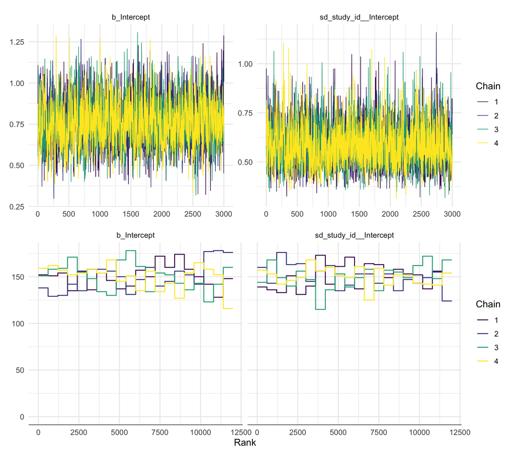

Figure 2: MCMC trace plots and rank histograms for the mortality model

```r
p_trace <- mcmc_trace(fit_mort, pars = c("b_Intercept", "sd_study_id__Intercept"))
p_rank  <- mcmc_rank_overlay(fit_mort, pars = c("b_Intercept", "sd_study_id__Intercept"))
p_trace / p_rank
```

### 4.3.5 Combined Results Table

```r
tibble(
  Outcome = rep(c("Mortality", "Persistent Bacteremia"), each = 2),
  Method = rep(c("Frequentist REML", "Bayesian RE"), 2),
  `Pooled OR` = c(
    round(exp(coef(rma_mort)), 2), round(exp(median(mu_mort)), 2),
    round(exp(coef(rma_pb)), 2), round(exp(median(mu_pb)), 2)
  ),
  `95% CI/CrI` = c(
    paste0(round(exp(rma_mort$ci.lb), 2), "–", round(exp(rma_mort$ci.ub), 2)),
    paste0(round(exp(quantile(mu_mort, 0.025)), 2), "–", round(exp(quantile(mu_mort, 0.975)), 2)),
    paste0(round(exp(rma_pb$ci.lb), 2), "–", round(exp(rma_pb$ci.ub), 2)),
    paste0(round(exp(quantile(mu_pb, 0.025)), 2), "–", round(exp(quantile(mu_pb, 0.975)), 2))
  ),
  tau = c(
    round(sqrt(rma_mort$tau2), 2), round(median(post_mort$sd_study_id__Intercept), 2),
    round(sqrt(rma_pb$tau2), 2), round(median(post_pb$sd_study_id__Intercept), 2)
  )
)
```

Table 3: Pooled estimates: Frequentist vs Bayesian

```
# A tibble: 4 × 5
  Outcome               Method           `Pooled OR` `95% CI/CrI`   tau
  <chr>                 <chr>                  <dbl> <chr>        <dbl>
1 Mortality             Frequentist REML        2.18 1.72–2.75     0.57
2 Mortality             Bayesian RE             2.13 1.67–2.82     0.58
3 Persistent Bacteremia Frequentist REML        7.24 2.07–25.38    1.61
4 Persistent Bacteremia Bayesian RE             3.96 1.07–11.31    1.59
```

# 5 Forest Plots

## 5.1 Mortality Forest Plot

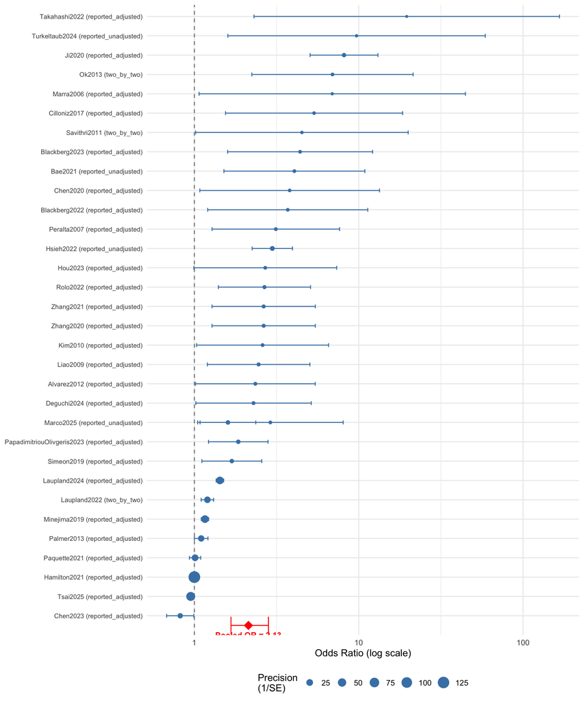

Figure 3: Forest plot — Mortality (k=33). Studies ordered by effect size. Diamond = Bayesian pooled estimate.

```r
# Build forest data
mort_forest <- es_mort |>
  mutate(
    or = exp(yi),
    ci_lo = exp(yi - 1.96 * sei),
    ci_hi = exp(yi + 1.96 * sei),
    label = paste0(study_id, " (", es_source, ")")
  ) |>
  arrange(yi)

mort_forest$order <- seq_len(nrow(mort_forest))

# Bayesian pooled estimate
pooled_or <- exp(median(mu_mort))
pooled_lo <- exp(quantile(mu_mort, 0.025))
pooled_hi <- exp(quantile(mu_mort, 0.975))

ggplot(mort_forest, aes(x = or, y = reorder(label, yi))) +
  geom_vline(xintercept = 1, linetype = "dashed", color = "grey50") +
  geom_point(aes(size = 1/sei), color = "steelblue") +
  geom_errorbarh(aes(xmin = ci_lo, xmax = ci_hi), height = 0.2, color = "steelblue") +
  annotate("point", x = pooled_or, y = 0.5, shape = 18, size = 5, color = "red") +
  annotate("errorbarh", xmin = pooled_lo, xmax = pooled_hi, y = 0.5, height = 0.3, color = "red") +
  annotate("text", x = pooled_or, y = 0, label = paste0("Pooled OR = ", round(pooled_or, 2)),
           hjust = 0.5, size = 3.5, fontface = "bold", color = "red") +
  scale_x_log10() +
  labs(x = "Odds Ratio (log scale)", y = NULL, size = "Precision\n(1/SE)") +
  theme(
    axis.text.y = element_text(size = 8),
    legend.position = "bottom"
  )
```

## 5.2 Persistent Bacteremia Forest Plot

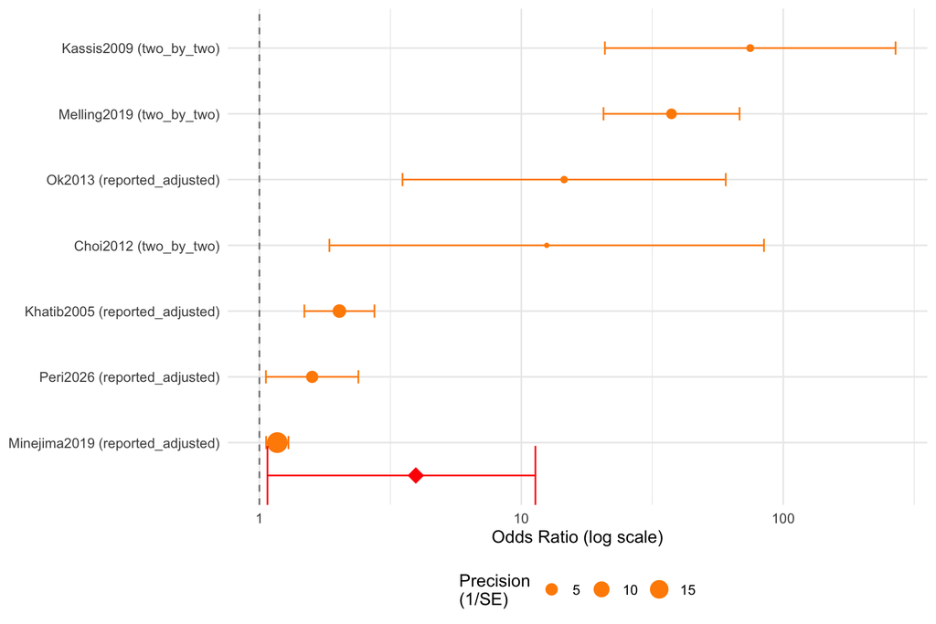

Figure 4: Forest plot — Persistent Bacteremia

```r
pb_forest <- es_pb |>
  mutate(
    or = exp(yi),
    ci_lo = exp(yi - 1.96 * sei),
    ci_hi = exp(yi + 1.96 * sei),
    label = paste0(study_id, " (", es_source, ")")
  ) |>
  arrange(yi)

pooled_or_pb <- exp(median(mu_pb))
pooled_lo_pb <- exp(quantile(mu_pb, 0.025))
pooled_hi_pb <- exp(quantile(mu_pb, 0.975))

ggplot(pb_forest, aes(x = or, y = reorder(label, yi))) +
  geom_vline(xintercept = 1, linetype = "dashed", color = "grey50") +
  geom_point(aes(size = 1/sei), color = "darkorange") +
  geom_errorbarh(aes(xmin = ci_lo, xmax = ci_hi), height = 0.2, color = "darkorange") +
  annotate("point", x = pooled_or_pb, y = 0.5, shape = 18, size = 5, color = "red") +
  annotate("errorbarh", xmin = pooled_lo_pb, xmax = pooled_hi_pb, y = 0.5, height = 0.3, color = "red") +
  scale_x_log10() +
  labs(x = "Odds Ratio (log scale)", y = NULL, size = "Precision\n(1/SE)") +
  theme(legend.position = "bottom")
```

## 5.3 Bayesian Posterior Density Comparison

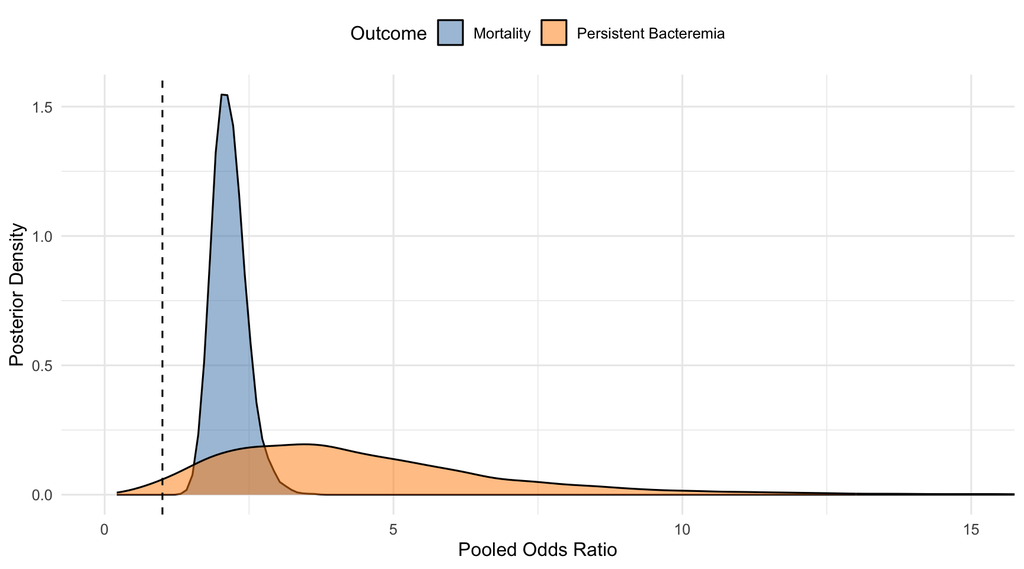

Figure 5: Posterior distributions of pooled OR for each outcome

```r
tibble(
  Outcome = rep(c("Mortality", "Persistent Bacteremia"), c(length(mu_mort), length(mu_pb))),
  OR = c(exp(mu_mort), exp(mu_pb))
) |>
  ggplot(aes(x = OR, fill = Outcome)) +
  geom_density(alpha = 0.5) +
  geom_vline(xintercept = 1, linetype = "dashed") +
  scale_fill_manual(values = c("Mortality" = "steelblue", "Persistent Bacteremia" = "darkorange")) +
  coord_cartesian(xlim = c(0, 15)) +
  labs(x = "Pooled Odds Ratio", y = "Posterior Density") +
  theme(legend.position = "top")
```

# 6 Publication Bias Assessment

## 6.1 Funnel Plot

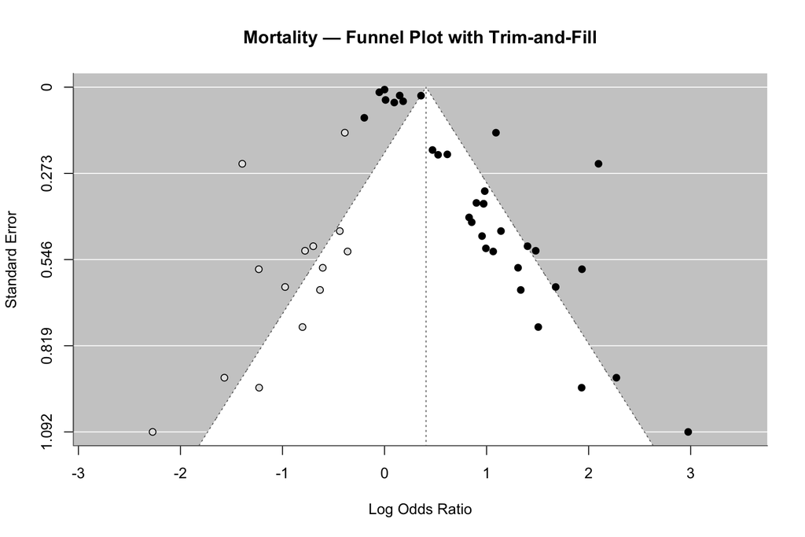

Figure 6: Funnel plot for mortality studies with trim-and-fill imputed studies

```r
# Trim-and-fill
tf_mort <- trimfill(rma_mort, side = "left")

funnel(tf_mort, xlab = "Log Odds Ratio", main = "Mortality — Funnel Plot with Trim-and-Fill")
```

## 6.2 Egger’s Regression Test

```r
regtest_mort <- regtest(rma_mort, model = "lm")
cat("Egger's regression test for funnel asymmetry (Mortality):\n")
```

```
Egger's regression test for funnel asymmetry (Mortality):
```

```r
cat("  z =", round(regtest_mort$zval, 3), "\n")
```

```
  z = 5.359
```

```r
cat("  p =", formatC(regtest_mort$pval, format = "e", digits = 3), "\n")
```

```
  p = 7.665e-06
```

```r
cat("  Interpretation:", ifelse(regtest_mort$pval < 0.05,
  "Significant asymmetry detected", "No significant asymmetry"), "\n")
```

```
  Interpretation: Significant asymmetry detected
```

## 6.3 Trim-and-Fill Adjusted Estimate

```r
cat("Original REML:   OR =", round(exp(coef(rma_mort)), 2),
    "95% CI", round(exp(rma_mort$ci.lb), 2), "–", round(exp(rma_mort$ci.ub), 2), "\n")
```

```
Original REML:   OR = 2.18 95% CI 1.72 – 2.75
```

```r
cat("Trim-and-Fill:   OR =", round(exp(coef(tf_mort)), 2),
    "95% CI", round(exp(tf_mort$ci.lb), 2), "–", round(exp(tf_mort$ci.ub), 2), "\n")
```

```
Trim-and-Fill:   OR = 1.5 95% CI 1.15 – 1.96
```

```r
cat("Imputed studies:", tf_mort$k0, "\n")
```

```
Imputed studies: 14
```

## 6.4 Frequentist Selection Models

```r
# Step-function selection model (Vevea & Hedges)
sel_mort <- try(selmodel(rma_mort, type = "stepfun", steps = 0.05), silent = TRUE)

if (!inherits(sel_mort, "try-error")) {
  sel_beta <- as.numeric(sel_mort$beta)
  sel_ci_lb <- as.numeric(sel_mort$ci.lb)
  sel_ci_ub <- as.numeric(sel_mort$ci.ub)
  sel_delta <- as.numeric(sel_mort$delta)
  cat("Step-function selection model:\n")
  cat("  Adjusted OR:", round(exp(sel_beta[1]), 2), "\n")
  cat("  95% CI:", round(exp(sel_ci_lb[1]), 2), "–", round(exp(sel_ci_ub[1]), 2), "\n")
  cat("  Selection parameter delta:", round(sel_delta[1], 3), "\n")
  cat("  (delta = probability ratio for non-significant vs significant studies)\n")
}
```

```
Step-function selection model:
  Adjusted OR: 1.09
  95% CI: 0.67 – 1.79
  Selection parameter delta: 1
  (delta = probability ratio for non-significant vs significant studies)
```

## 6.5 Bayesian Selection Models (Stan)

To address limitations of frequentist selection models with sparse non-significant studies, we implement fully Bayesian selection models that regularize the selection parameter via informative priors.

```r
library(rstan)
rstan_options(auto_write = TRUE)
options(mc.cores = parallel::detectCores())

selection_code <- "
data {
  int<lower=1> K;
  vector[K] y;
  vector<lower=0>[K] se;
  int<lower=0,upper=1> sig[K];
}
parameters {
  real mu;
  real<lower=0> tau;
  vector[K] theta;
  real<lower=0,upper=1> delta;
}
model {
  // Priors
  mu ~ normal(0, 1);
  tau ~ cauchy(0, 0.5);
  delta ~ beta(2, 5);  // Skeptical: mean = 0.29

  // Random effects
  theta ~ normal(mu, tau);

  // Likelihood
  y ~ normal(theta, se);

  // Selection mechanism
  for (k in 1:K) {
    if (sig[k] == 0) {
      target += log(delta);
    }
  }
}
"

# Prepare data
mort_sig <- with(es_mort, as.integer(abs(yi / sei) > 1.96))

stan_data <- list(
  K = nrow(es_mort),
  y = es_mort$yi,
  se = es_mort$sei,
  sig = mort_sig
)

fit_selection <- stan(
  model_code = selection_code,
  data = stan_data,
  chains = 4, iter = 4000, warmup = 1000,
  seed = 42
)
```

```r
sel_draws <- as.data.frame(fit_selection)

cat("Bayesian Selection Model (skeptical prior, delta ~ Beta(2,5)):\n")
```

```
Bayesian Selection Model (skeptical prior, delta ~ Beta(2,5)):
```

```r
cat("  Pooled OR:", round(exp(median(sel_draws$mu)), 2), "\n")
```

```
  Pooled OR: 2.14
```

```r
cat("  95% CrI:", round(exp(quantile(sel_draws$mu, 0.025)), 2), "–",
    round(exp(quantile(sel_draws$mu, 0.975)), 2), "\n")
```

```
  95% CrI: 1.71 – 2.79
```

```r
cat("  P(OR > 1):", round(100 * mean(sel_draws$mu > 0), 1), "%\n\n")
```

```
  P(OR > 1): 100 %
```

```r
cat("  Selection delta (median):", round(median(sel_draws$delta), 2), "\n")
```

```
  Selection delta (median): 0.5
```

```r
cat("  delta 95% CrI:", round(quantile(sel_draws$delta, 0.025), 2), "–",
    round(quantile(sel_draws$delta, 0.975), 2), "\n")
```

```
  delta 95% CrI: 0.22 – 0.79
```

## 6.6 Publication Bias Summary

```r
# Build summary table
bias_summary <- tibble(
  Method = c(
    "Unadjusted (REML)",
    "Trim-and-Fill",
    "Freq. Step-function",
    "Bayesian Selection (skeptical prior)"
  ),
  `Pooled OR` = c(
    round(exp(coef(rma_mort)), 2),
    round(exp(coef(tf_mort)), 2),
    if (!inherits(sel_mort, "try-error")) round(exp(sel_beta[1]), 2) else NA,
    round(exp(median(sel_draws$mu)), 2)
  ),
  `95% CI/CrI` = c(
    paste0(round(exp(rma_mort$ci.lb), 2), "–", round(exp(rma_mort$ci.ub), 2)),
    paste0(round(exp(tf_mort$ci.lb), 2), "–", round(exp(tf_mort$ci.ub), 2)),
    if (!inherits(sel_mort, "try-error")) paste0(round(exp(sel_ci_lb[1]), 2), "–", round(exp(sel_ci_ub[1]), 2)) else "—",
    paste0(round(exp(quantile(sel_draws$mu, 0.025)), 2), "–", round(exp(quantile(sel_draws$mu, 0.975)), 2))
  ),
  Interpretation = c(
    "Reference estimate",
    "Conservative lower bound",
    "Likely over-adjusts (sparse non-sig studies)",
    "Robust — regularized selection parameter"
  )
)

bias_summary
```

Table 4: Publication bias assessment — comparison of adjustment methods

```
# A tibble: 4 × 4
  Method                               `Pooled OR` `95% CI/CrI` Interpretation
  <chr>                                      <dbl> <chr>        <chr>
1 Unadjusted (REML)                           2.18 1.72–2.75    Reference estim…
2 Trim-and-Fill                               1.5  1.15–1.96    Conservative lo…
3 Freq. Step-function                         1.09 0.67–1.79    Likely over-adj…
4 Bayesian Selection (skeptical prior)        2.14 1.71–2.79    Robust — regula…
```

# 7 Sensitivity Analyses

## 7.1 Outlier Exclusion — Mortality

Ji2020 reports an extreme effect size. We re-estimate the model excluding this study.

```r
es_mort_no_ji <- es_mort |> filter(study_id != "Ji2020")

fit_mort_sens <- brm(
  yi | se(sei) ~ 1 + (1 | study_id),
  data = es_mort_no_ji,
  prior = meta_priors,
  backend = stan_backend,
  chains = 4, iter = 4000, warmup = 1000,
  control = list(adapt_delta = 0.95),
  seed = 42
)

post_mort_sens <- as_draws_df(fit_mort_sens)
mu_mort_sens <- post_mort_sens$b_Intercept

cat("Mortality sensitivity (excluding Ji2020):\n")
cat("  OR:", round(exp(median(mu_mort_sens)), 2), "\n")
cat("  95% CrI:", round(exp(quantile(mu_mort_sens, 0.025)), 2), "–",
    round(exp(quantile(mu_mort_sens, 0.975)), 2), "\n")
cat("  P(OR > 1):", round(100 * mean(mu_mort_sens > 0), 1), "%\n")
```

[output not shown]

## 7.2 Outlier Exclusion — Persistent Bacteremia

The persistent bacteremia pool is influenced by studies with extreme estimates from sparse 2×2 cells (Melling2019, Kassis2009).

```r
es_pb_sens <- es_pb |> filter(!study_id %in% c("Melling2019", "Kassis2009"))

fit_pb_sens <- brm(
  yi | se(sei) ~ 1 + (1 | study_id),
  data = es_pb_sens,
  prior = meta_priors,
  backend = stan_backend,
  chains = 4, iter = 4000, warmup = 1000,
  control = list(adapt_delta = 0.95),
  seed = 42
)

post_pb_sens <- as_draws_df(fit_pb_sens)
mu_pb_sens <- post_pb_sens$b_Intercept

cat("Persistent bacteremia sensitivity (excluding Melling2019, Kassis2009):\n")
cat("  OR:", round(exp(median(mu_pb_sens)), 2), "\n")
cat("  95% CrI:", round(exp(quantile(mu_pb_sens, 0.025)), 2), "–",
    round(exp(quantile(mu_pb_sens, 0.975)), 2), "\n")
cat("  P(OR > 1):", round(100 * mean(mu_pb_sens > 0), 1), "%\n")
```

[output not shown]

## 7.3 Prior Sensitivity — Mortality

We vary prior specifications to assess robustness of the pooled mortality estimate.

```r
# Wider intercept prior
fit_mort_wide <- brm(
  yi | se(sei) ~ 1 + (1 | study_id),
  data = es_mort,
  prior = c(
    prior(normal(0, 2), class = "Intercept"),
    prior(cauchy(0, 0.5), class = "sd")
  ),
  backend = stan_backend,
  chains = 4, iter = 4000, warmup = 1000,
  control = list(adapt_delta = 0.95),
  seed = 42
)

# Skeptical prior (centered toward null)
fit_mort_skep <- brm(
  yi | se(sei) ~ 1 + (1 | study_id),
  data = es_mort,
  prior = c(
    prior(normal(0, 0.5), class = "Intercept"),
    prior(cauchy(0, 0.5), class = "sd")
  ),
  backend = stan_backend,
  chains = 4, iter = 4000, warmup = 1000,
  control = list(adapt_delta = 0.95),
  seed = 42
)

# Half-normal tau prior
fit_mort_hn <- brm(
  yi | se(sei) ~ 1 + (1 | study_id),
  data = es_mort,
  prior = c(
    prior(normal(0, 1), class = "Intercept"),
    prior(normal(0, 0.5), class = "sd")
  ),
  backend = stan_backend,
  chains = 4, iter = 4000, warmup = 1000,
  control = list(adapt_delta = 0.95),
  seed = 42
)
```

```r
extract_or <- function(fit, label) {
  post <- as_draws_df(fit)
  mu <- post$b_Intercept
  tibble(
    Prior = label,
    `Pooled OR` = round(exp(median(mu)), 2),
    `95% CrI` = paste0(round(exp(quantile(mu, 0.025)), 2), "–", round(exp(quantile(mu, 0.975)), 2)),
    `P(OR>1)` = paste0(round(100 * mean(mu > 0), 1), "%")
  )
}

bind_rows(
  extract_or(fit_mort, "Primary: N(0,1) + HC(0,0.5)"),
  extract_or(fit_mort_wide, "Wide: N(0,2) + HC(0,0.5)"),
  extract_or(fit_mort_skep, "Skeptical: N(0,0.5) + HC(0,0.5)"),
  extract_or(fit_mort_hn, "Half-Normal tau: N(0,1) + HN(0,0.5)")
)
```

Table 5: Prior sensitivity analysis — Mortality

```
# A tibble: 4 × 4
  Prior                               `Pooled OR` `95% CrI` `P(OR>1)`
  <chr>                                     <dbl> <chr>     <chr>
1 Primary: N(0,1) + HC(0,0.5)                2.13 1.67–2.82 100%
2 Wide: N(0,2) + HC(0,0.5)                   2.16 1.7–2.84  100%
3 Skeptical: N(0,0.5) + HC(0,0.5)            2.07 1.64–2.66 100%
4 Half-Normal tau: N(0,1) + HN(0,0.5)        2.13 1.69–2.76 100%
```

## 7.4 Sensitivity Summary

```r
bind_rows(
  tibble(Analysis = "Primary Bayesian (k=33)", OR = round(exp(median(mu_mort)), 2),
         CrI = paste0(round(exp(quantile(mu_mort, 0.025)), 2), "–", round(exp(quantile(mu_mort, 0.975)), 2))),
  tibble(Analysis = "Excl. Ji2020 (k=32)", OR = round(exp(median(mu_mort_sens)), 2),
         CrI = paste0(round(exp(quantile(mu_mort_sens, 0.025)), 2), "–", round(exp(quantile(mu_mort_sens, 0.975)), 2))),
  tibble(Analysis = "Trim-and-Fill adjusted", OR = round(exp(coef(tf_mort)), 2),
         CrI = paste0(round(exp(tf_mort$ci.lb), 2), "–", round(exp(tf_mort$ci.ub), 2))),
  tibble(Analysis = "Bayesian Selection (skeptical)", OR = round(exp(median(sel_draws$mu)), 2),
         CrI = paste0(round(exp(quantile(sel_draws$mu, 0.025)), 2), "–", round(exp(quantile(sel_draws$mu, 0.975)), 2)))
)
```

Table 6: Complete sensitivity analysis summary — Mortality

```
# A tibble: 4 × 3
  Analysis                          OR CrI
  <chr>                          <dbl> <chr>
1 Primary Bayesian (k=33)         2.13 1.67–2.82
2 Excl. Ji2020 (k=32)             1.96 1.58–2.51
3 Trim-and-Fill adjusted          1.5  1.15–1.96
4 Bayesian Selection (skeptical)  2.14 1.71–2.79
```

# 8 Meta-Regression

We test whether prespecified study-level moderators explain heterogeneity in the mortality effect via Bayesian meta-regression. Each moderator is tested in a separate univariable model.

## 8.1 Pathogen Class

```r
es_mort_complete_path <- es_mort |> filter(!is.na(pathogen_class))

fit_pathogen <- brm(
  yi | se(sei) ~ 1 + pathogen_class + (1 | study_id),
  data = es_mort_complete_path,
  prior = c(
    prior(normal(0, 1), class = "Intercept"),
    prior(normal(0, 0.5), class = "b"),
    prior(cauchy(0, 0.5), class = "sd")
  ),
  backend = stan_backend,
  chains = 4, iter = 4000, warmup = 1000,
  control = list(adapt_delta = 0.95),
  seed = 42
)

summary(fit_pathogen)
```

## 8.2 S. aureus vs Other Pathogens

```r
fit_saureus <- brm(
  yi | se(sei) ~ 1 + organism_saureus + (1 | study_id),
  data = es_mort,
  prior = c(
    prior(normal(0, 1), class = "Intercept"),
    prior(normal(0, 0.5), class = "b"),
    prior(cauchy(0, 0.5), class = "sd")
  ),
  backend = stan_backend,
  chains = 4, iter = 4000, warmup = 1000,
  control = list(adapt_delta = 0.95),
  seed = 42
)

summary(fit_saureus)
```

## 8.3 Risk of Bias

```r
fit_rob <- brm(
  yi | se(sei) ~ 1 + rob_binary + (1 | study_id),
  data = es_mort,
  prior = c(
    prior(normal(0, 1), class = "Intercept"),
    prior(normal(0, 0.5), class = "b"),
    prior(cauchy(0, 0.5), class = "sd")
  ),
  backend = stan_backend,
  chains = 4, iter = 4000, warmup = 1000,
  control = list(adapt_delta = 0.95),
  seed = 42
)

summary(fit_rob)
```

## 8.4 Blood Culture System

```r
es_mort_bcs <- es_mort |> filter(!is.na(blood_culture_system_clean))

fit_bcs <- brm(
  yi | se(sei) ~ 1 + bcs_binary + (1 | study_id),
  data = es_mort_bcs,
  prior = c(
    prior(normal(0, 1), class = "Intercept"),
    prior(normal(0, 0.5), class = "b"),
    prior(cauchy(0, 0.5), class = "sd")
  ),
  backend = stan_backend,
  chains = 4, iter = 4000, warmup = 1000,
  control = list(adapt_delta = 0.95),
  seed = 42
)

summary(fit_bcs)
```

## 8.5 Meta-Regression Summary

```r
extract_metareg <- function(fit, moderator) {
  post <- as_draws_df(fit)
  # Get coefficient names excluding Intercept and sd
  coef_names <- names(post)[str_detect(names(post), "^b_") & names(post) != "b_Intercept"]

  map_dfr(coef_names, function(cn) {
    vals <- post[[cn]]
    tibble(
      Moderator = moderator,
      Coefficient = str_remove(cn, "^b_"),
      Estimate = round(median(vals), 3),
      `95% CrI` = paste0(round(quantile(vals, 0.025), 3), " to ", round(quantile(vals, 0.975), 3)),
      `P(β ≠ 0)` = paste0(round(100 * (1 - 2 * min(mean(vals > 0), mean(vals < 0))), 1), "%"),
      `CrI includes 0` = ifelse(quantile(vals, 0.025) < 0 & quantile(vals, 0.975) > 0, "Yes", "No")
    )
  })
}

bind_rows(
  extract_metareg(fit_pathogen, "Pathogen class"),
  extract_metareg(fit_saureus, "S. aureus"),
  extract_metareg(fit_rob, "Risk of bias"),
  extract_metareg(fit_bcs, "Blood culture system")
)
```

Table 7: Meta-regression results — moderator effects on mortality log-OR

```
# A tibble: 6 × 6
  Moderator           Coefficient Estimate `95% CrI` `P(β ≠ 0)` `CrI includes 0`
  <chr>               <chr>          <dbl> <chr>     <chr>      <chr>
1 Pathogen class      pathogen_c…    0.069 -0.406 t… 22.9%      Yes
2 Pathogen class      pathogen_c…   -0.133 -0.659 t… 38.8%      Yes
3 S. aureus           organism_s…   -0.157 -0.61 to… 48.9%      Yes
4 Risk of bias        rob_binary…    0.048 -0.417 t… 17.2%      Yes
5 Blood culture syst… bcs_binary…    0.187 -0.28 to… 56.8%      Yes
6 Blood culture syst… bcs_binary…   -0.258 -0.884 t… 60.1%      Yes
```

None of the tested moderators explained a meaningful proportion of heterogeneity. All 95% credible intervals for moderator coefficients included zero, indicating that the TTP–mortality association is consistent across pathogen classes, organisms, risk of bias strata, and blood culture detection systems.

# 9 Discussion

## 9.2 Heterogeneity

Substantial between-study heterogeneity was observed (I² ≈ 99%, τ ≈ 0.58 for mortality). Meta-regression found no moderator — pathogen class, *S. aureus* specificity, risk of bias, or blood culture system — that explained this heterogeneity. This suggests that unmeasured factors (TTP cutpoint variation, patient severity, antibiotic timing, institutional protocols) drive the between-study variability.

## 9.3 Publication Bias

Significant funnel asymmetry was detected (Egger’s p < 0.001). Multiple adjustment approaches were applied:

## 9.5 Limitations

1. **Cutpoint heterogeneity** — TTP “short” thresholds ranged from ≤8h to ≤16h across studies, a source of irreducible clinical heterogeneity
2. **Outcome definition variability** — mortality timepoints ranged from 14-day to in-hospital; persistent bacteremia definitions varied
3. **Publication bias** — despite Bayesian robustness, the high proportion of significant studies (91%) exceeds expectations and suggests some degree of selective reporting
4. **Observational evidence only** — all included studies are observational, limiting causal inference
5. **Continuous TTP effects excluded** — two studies reporting OR per hour of TTP were excluded from the main pool due to incompatible effect scales